# HOBO data script

Vincyane Badouard

2023-09-04

**les données très fortes de lumière = sunflex étude sunflecks**

Objectives:

- open the HOBO data

- create a script to open HOBO data in several folders

- prepare HOBO data for analysis - spatialiser tous les capteurs en x,y (trilateration) (A FAIRE) - descriptive analysis

Problematics:

- A quelle échelle la variabilité est la plus forte (saison, mois, jour, jour/nuit, 15min) ?

- La température de l’air et la lumière sont-elles liées à l’ouverture de canopée ? à la topographie ?

Variables à calculer : moyenne, sd, coefficient de variation, min, max :

- de l’année

- diurne

- nocturne

- saison sèche

- saison des pluies

# Packages

# Read

# Combine data and environment

# Rename files

# Understand the HOBO file

Les 30 capteurs ont été posés le 30/03/23 et ont commencé à collecter des données ce même jour à 18h. Ils collectent bien toutes les 15 minutes.

```
##  [1] "HoboID"
##  [2] "#"
##  [3] "Date et heure (French Guiana Standard Time)"
##  [4] "Ch: 1 - Température   (°C)"
##  [5] "Ch: 2 - Lumière   (lux)"
##  [6] "...1"
##  [7] "Site"
##  [8] "Plot"
##  [9] "SubPlot"
## [10] "TomstID"
## [11] "TomstSensorNum"
## [12] "Transect"
## [13] "LightHabitat"
## [14] "TopoHabitat"
## [15] "LayonEdge"
## [16] "FieldDate"
## [17] "TreeNum1"
## [18] "TreeNum2"
## [19] "TreeNum3"
## [20] "DTree1"
## [21] "DTree2"
## [22] "DTree3"
```

```
## Sensors number range: 1 30
```

[output not shown]

# Prepare HOBO data for analysis

Rename variables

## Manage date and hours

```
## [1] "character"
```

```
## Sensors time range: 1680199200 1685011500
```

```
## The collect date: 19502
```

```
## Time difference of 56 days
```

## NA ?

# Relation between light and temperature

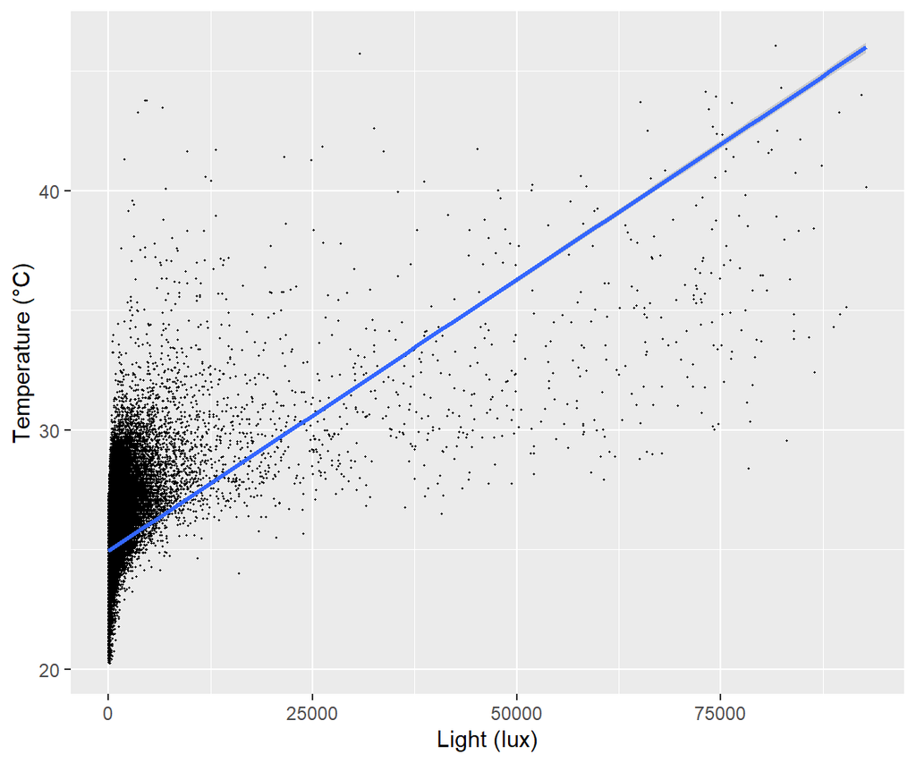

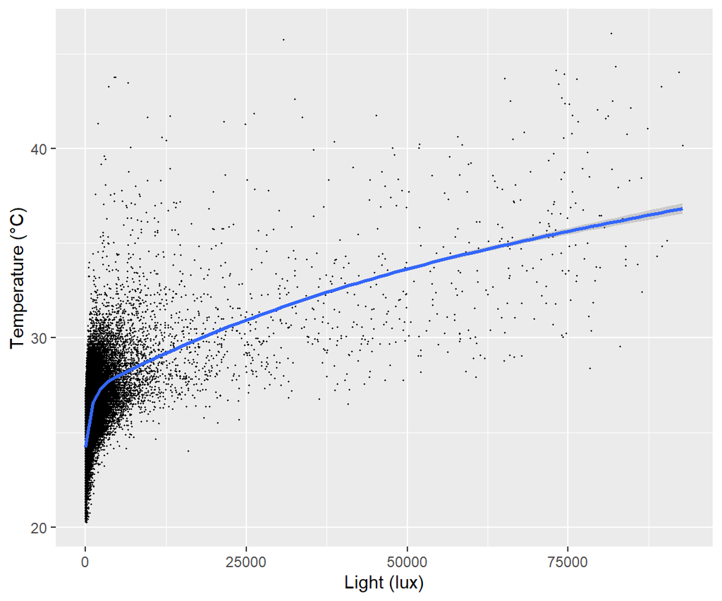

```
## cor: 0.4446962
```

# Day/night

See when it’s the night.

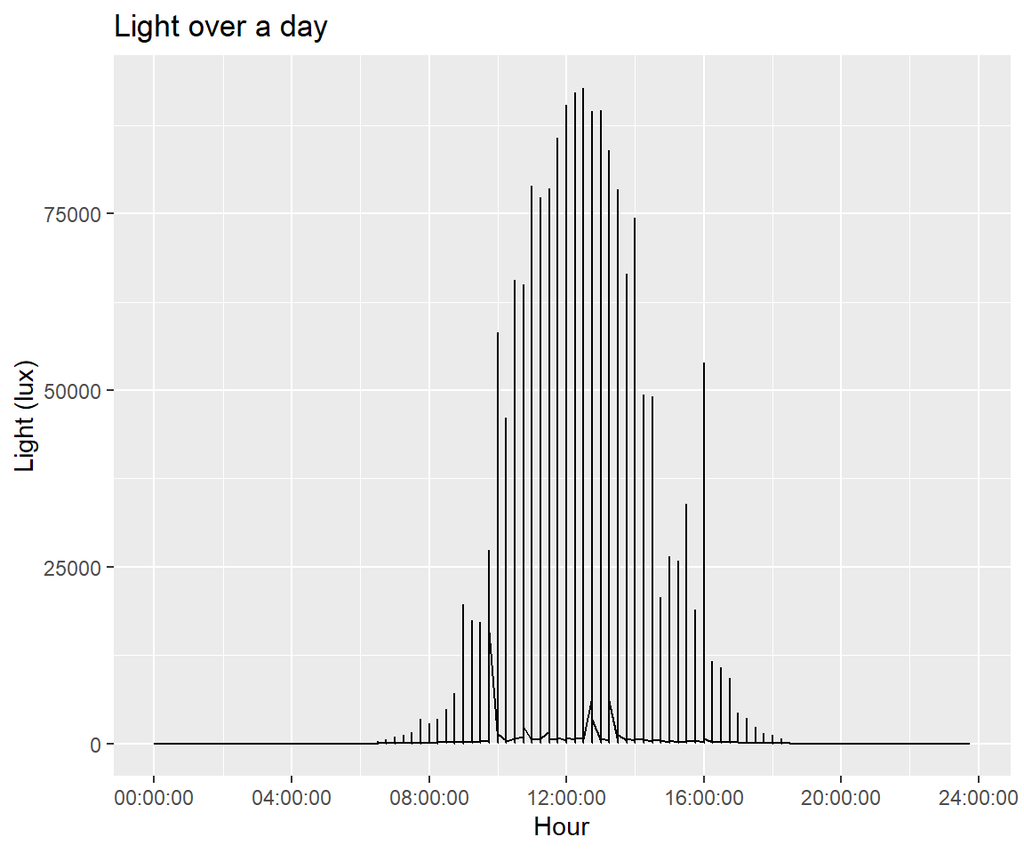

```
## Day: 06:15 - 18:45
```

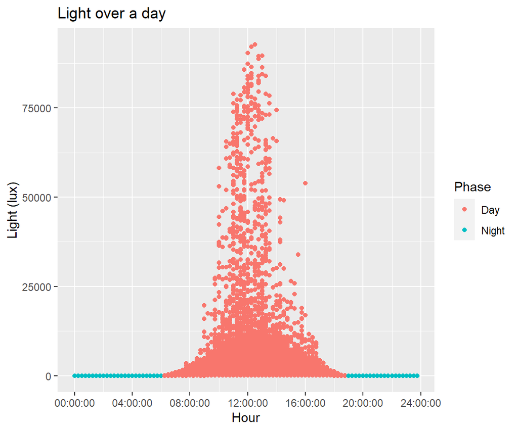

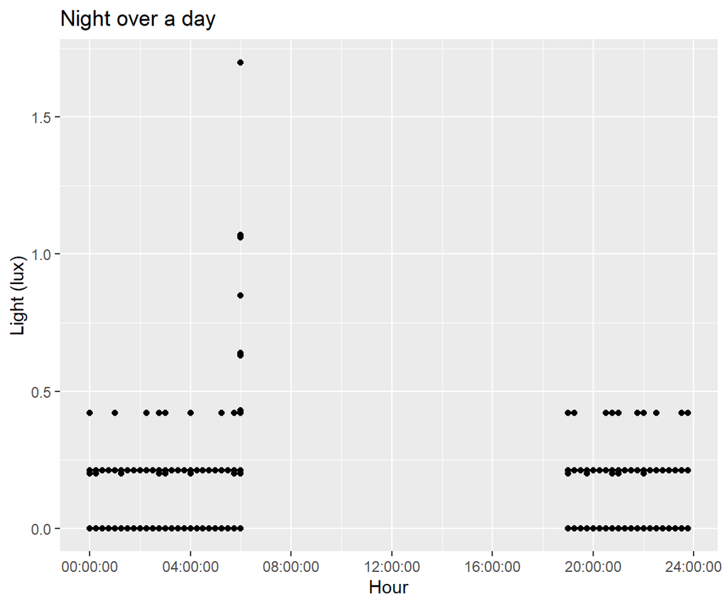

```
## Maximum light by night: 1.7
```

```
## Minimum light by day: 0
```

# Seasons

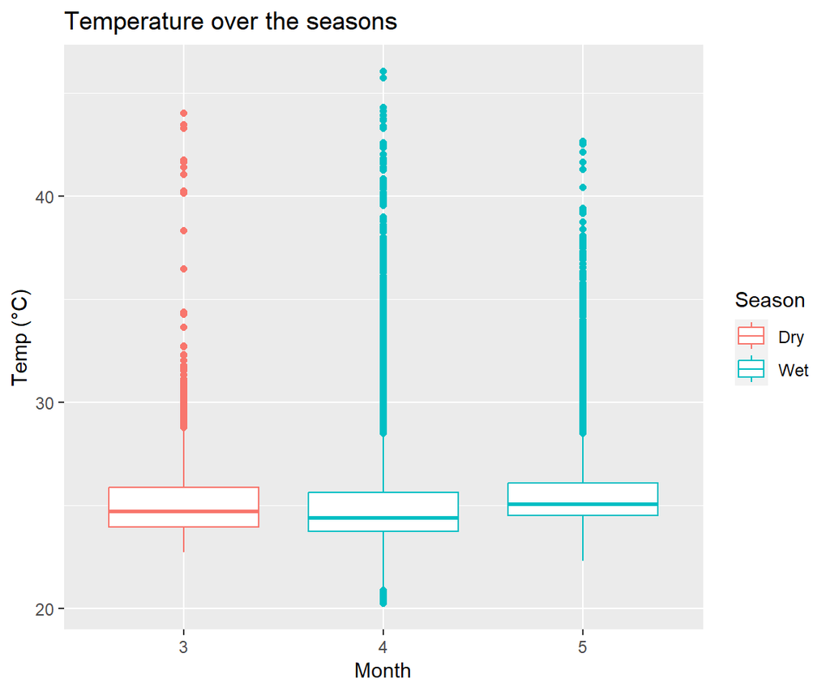

# Variables à calculer

à l’échelle du capteur :

- moyenne de l’année

- moyenne diurne

- moyenne nocturne

- moyenne saison sèche

- moyenne saison des pluies

- coefficient variation à ces échelles

# Stats dataset

# Some plots

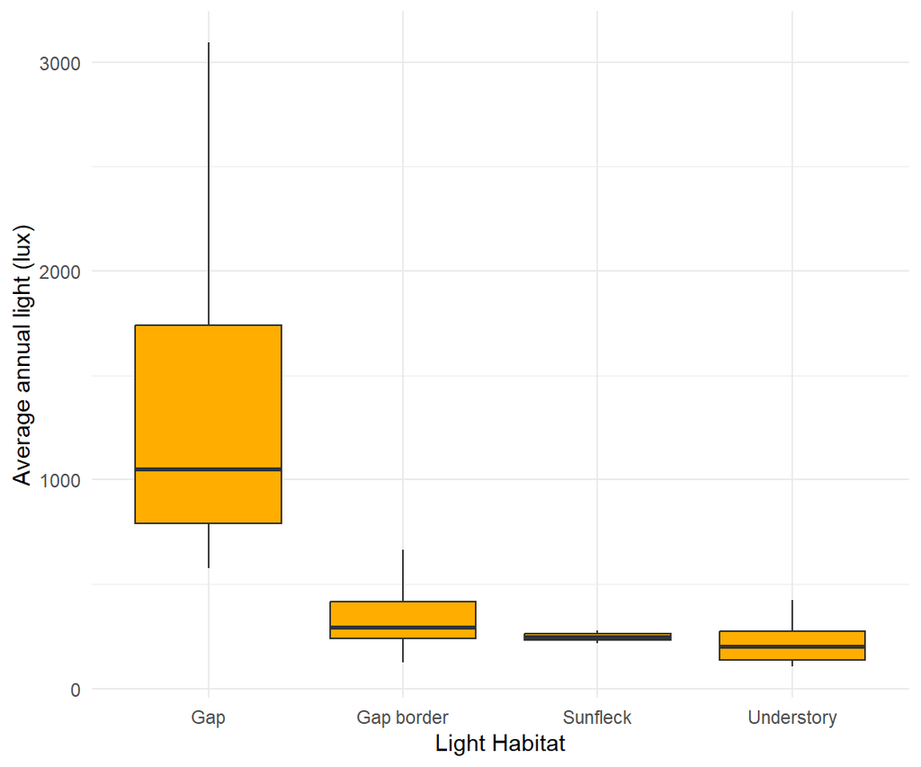

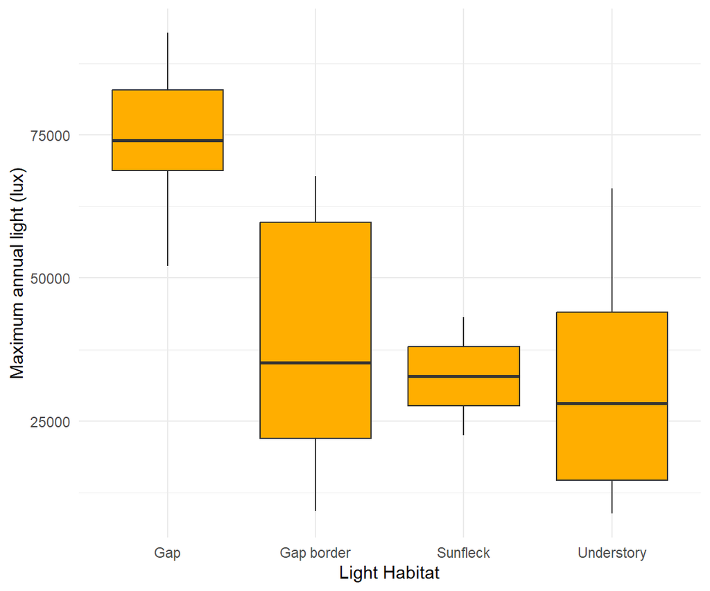

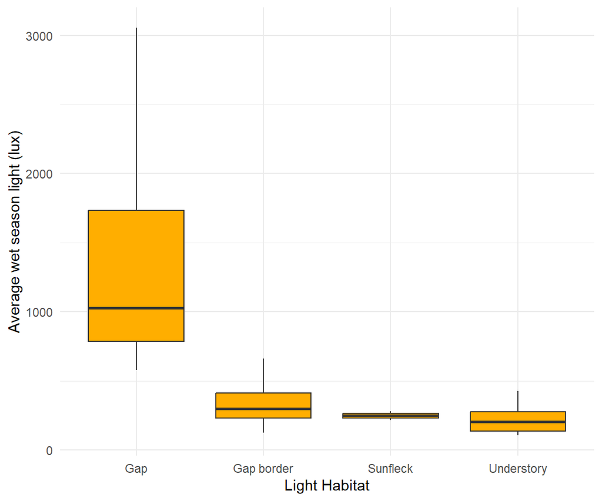

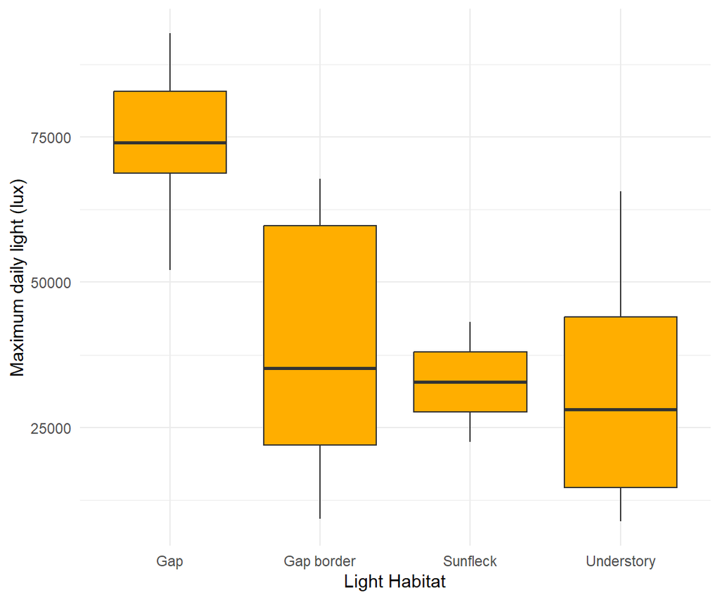

```
## Les gaps sont bien les zones les plus lumineuses. Le sous-bois connait des variations de lumière importantes au cours de la journée
```

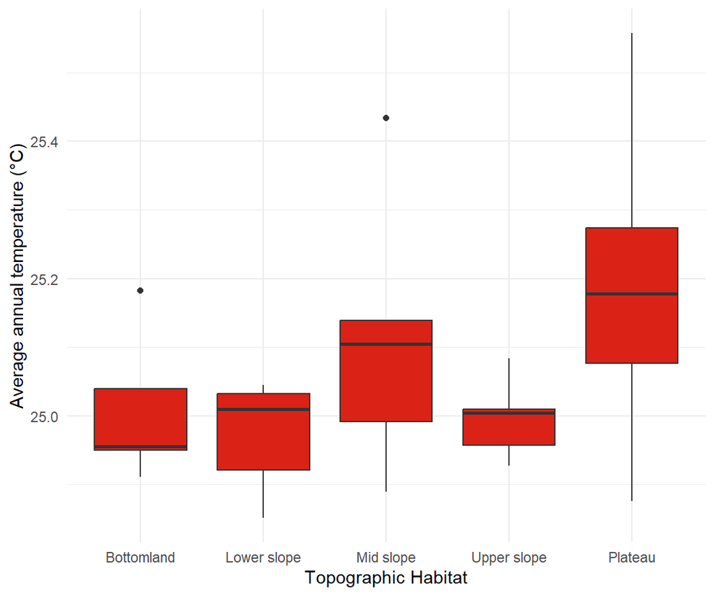

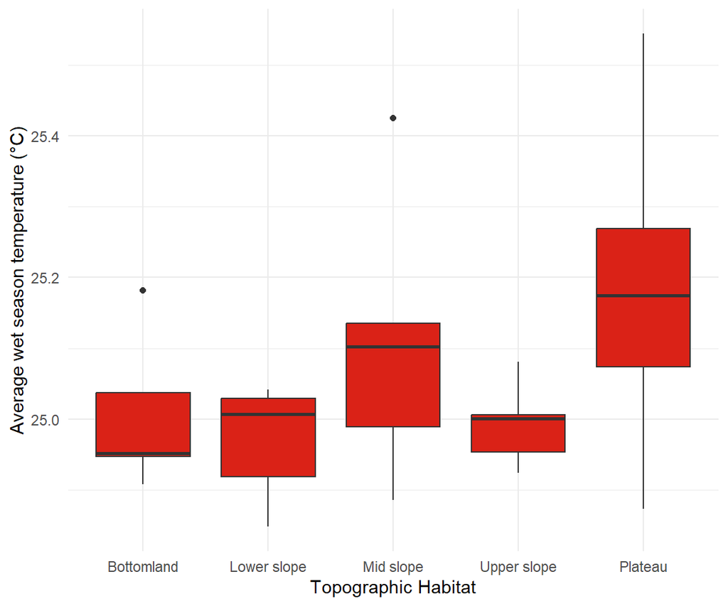

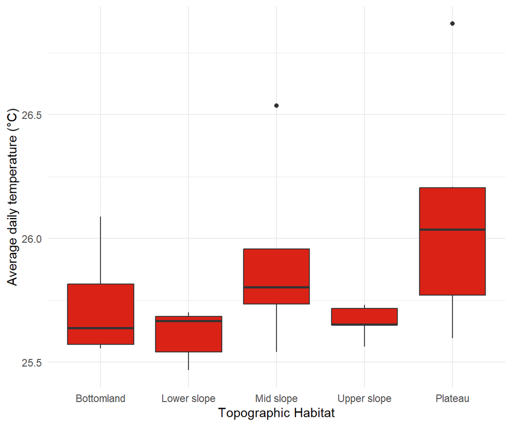

```
## La température augmente avec la topographie
```

# Correlation test

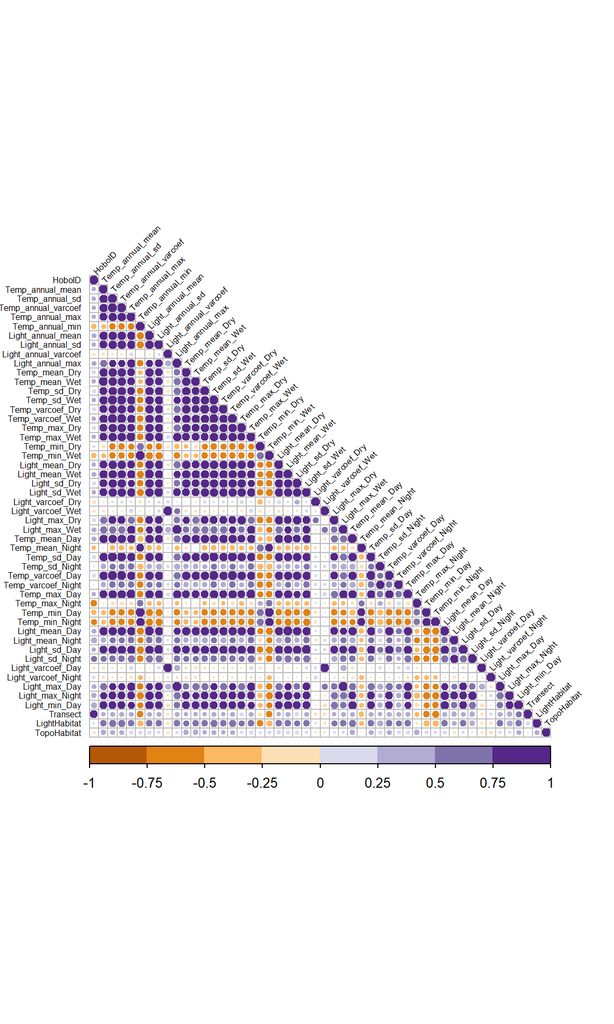

Ces métriques de lumière et de température ne semblent pas être fortement reliées à la topographie. Pourtant les boxplots laissent à penser que la température augmente du bas-fond vers le plateau.

Les relations à la topographie les plus importantes cor entre 0.25 et 0.5 :

- Average annual, dry, wet, day temperature
- Maximum night temperature
- Minimum day light

Sont lié à l’habitat lumineux : tout sauf les coefficient de variation et la température maximum nocturne.

# Sensors coordinates (mis de côté, à continuer)

## Trilateration

# Save the stats dataset